# Final

David Lau

5/3/2021

# Project Overview

In this notebook, I plan to wrangle some data regarding transportation options within New York City, particularly the subway and Uber ridesharing. In general, the subway is a far more economical option, costing only $2.75 ($2.50 in 2014 - the year in which the data was collected) as opposed to Uber rides, which have a minimum fare of $7.00 (https://www.investopedia.com/articles/personal-finance/021015/uber-versus-yellow-cabs-new-york-city.asp). Given this knowledge, I’ll investigate some criteria when choosing whether to take the train or call an Uber.

# Datasets

## Uber Data

I will be using the “Uber Pickups in New York City” dataset: https://www.kaggle.com/fivethirtyeight/uber-pickups-in-new-york-city

This dataset is fairly limited and only contains the latitude and longitude of the pickup location. Unfortunately, there is no data regarding the distance of the ride nor the dropout location, but the pickup location is sufficient for some meaningful analysis.

## MTA Data

Additionally, I will use a wrapper of the MTA API to gather information about each subway station: http://nycpulse.herokuapp.com/api

Particularly, I will use their `/stop` endpoint, which returns the name, latitude, and longitude of the subway station.

Unfortunately, this does not contain ridership statistics, which makes it difficult to make a direct comparison to the Uber dataset. However, there are still some aspects that can be analyzed just based on the location of the stations.

# Processing Data

## Uber Dataset

First, I will analyze the dataset of Uber rides. I will be using the raw data from 2014, which is split up into six files.

```r
uber_apr <- read_csv(here("data", "uber-raw-data-apr14.csv"))
uber_may <- read_csv(here("data", "uber-raw-data-may14.csv"))
uber_jun <- read_csv(here("data", "uber-raw-data-jun14.csv"))
uber_jul <- read_csv(here("data", "uber-raw-data-jul14.csv"))
uber_aug <- read_csv(here("data", "uber-raw-data-aug14.csv"))
uber_sep <- read_csv(here("data", "uber-raw-data-sep14.csv"))
uber_data <- rbind(uber_apr, uber_may, uber_jun, uber_jul, uber_aug, uber_sep)

dim(uber_data)
```

```
## [1] 4534327       4
```

```r
uber_data %>% head(10)
```

```
## # A tibble: 10 x 4
##    `Date/Time`        Lat   Lon Base
##    <chr>            <dbl> <dbl> <chr>
##  1 4/1/2014 0:11:00  40.8 -74.0 B02512
##  2 4/1/2014 0:17:00  40.7 -74.0 B02512
##  3 4/1/2014 0:21:00  40.7 -74.0 B02512
##  4 4/1/2014 0:28:00  40.8 -74.0 B02512
##  5 4/1/2014 0:33:00  40.8 -74.0 B02512
##  6 4/1/2014 0:33:00  40.7 -74.0 B02512
##  7 4/1/2014 0:39:00  40.7 -74.0 B02512
##  8 4/1/2014 0:45:00  40.8 -74.0 B02512
##  9 4/1/2014 0:55:00  40.8 -74.0 B02512
## 10 4/1/2014 1:01:00  40.8 -74.0 B02512
```

There are approximately 4.5 million samples in total.

First, I’ll parse the dates and times. Then, I’ll rename the columns to prepare them for plotting later.

```r
uber_data <- uber_data %>%
  mutate(`Date/Time` = mdy_hms(`Date/Time`, tz = "America/New_York"))

uber_data <- uber_data %>% rename(lat=Lat, lng=Lon)

uber_data %>% head(10)
```

```
## # A tibble: 10 x 4
##    `Date/Time`           lat   lng Base
##    <dttm>              <dbl> <dbl> <chr>
##  1 2014-04-01 00:11:00  40.8 -74.0 B02512
##  2 2014-04-01 00:17:00  40.7 -74.0 B02512
##  3 2014-04-01 00:21:00  40.7 -74.0 B02512
##  4 2014-04-01 00:28:00  40.8 -74.0 B02512
##  5 2014-04-01 00:33:00  40.8 -74.0 B02512
##  6 2014-04-01 00:33:00  40.7 -74.0 B02512
##  7 2014-04-01 00:39:00  40.7 -74.0 B02512
##  8 2014-04-01 00:45:00  40.8 -74.0 B02512
##  9 2014-04-01 00:55:00  40.8 -74.0 B02512
## 10 2014-04-01 01:01:00  40.8 -74.0 B02512
```

## MTA Dataset

The MTA data is a bit more split up and will require many API calls to gather. First, I will grab the list of stations from the API and then use that list to make requests for the location of each station. This operation takes quite a while since there are 985 stations.

```r
station_list_url <- "https://mtaapi.herokuapp.com/stations"
station_list <- station_list_url %>% fromJSON()

station_list <- data.frame(station_list)
station_list <- station_list %>%
  rename('StationId' = 'result.id', 'StationName' = 'result.name')

getStationLatLong <- function(stationId) {
  url <- paste0("https://mtaapi.herokuapp.com/stop?id=", stationId)
  url %>% fromJSON() %>% .[["result"]]
}

# The part that takes a long time
station_list <- station_list %>%
  rowwise() %>%
  mutate(`lat` = as.numeric(getStationLatLong(StationId) %>% .[["lat"]]), `lng` = as.numeric(getStationLatLong(StationId) %>% .[["lon"]]))

station_list
```

```
## # A tibble: 985 x 4
## # Rowwise:
##    StationId StationName                   lat   lng
##    <chr>     <chr>                       <dbl> <dbl>
##  1 901N      Grand Central - 42 St        40.8 -74.0
##  2 902N      Times Sq - 42 St             40.8 -74.0
##  3 902S      Times Sq - 42 St             40.8 -74.0
##  4 901S      Grand Central - 42 St        40.8 -74.0
##  5 101S      Van Cortlandt Park - 242 St  40.9 -73.9
##  6 103S      238 St                       40.9 -73.9
##  7 104S      231 St                       40.9 -73.9
##  8 106S      Marble Hill - 225 St         40.9 -73.9
##  9 107S      215 St                       40.9 -73.9
## 10 108S      207 St                       40.9 -73.9
## # … with 975 more rows
```

Earlier, I mentioned that the list of stations returned by the API had 985 entries. This seems a bit high. A quick Google search indicates that there are ~470 stations. Taking a look at the data, it appears that some entries are duplicated if they have both north and south bound lines at the same station. For our purposes, we won’t need both. Hence, I will remove duplicate entries that have the same name and location.

```r
unique_station_list = unique(station_list[ , 2:4])
unique_station_list <- as.data.frame(unique_station_list)
unique_station_list <- unique_station_list %>%
  mutate(station_row = row_number())
nrow(unique_station_list)
```

```
## [1] 490
```

```r
unique_station_list %>% head(10)
```

```
##                    StationName      lat       lng station_row
## 1        Grand Central - 42 St 40.75277 -73.97919           1
## 2             Times Sq - 42 St 40.75598 -73.98623           2
## 3  Van Cortlandt Park - 242 St 40.88925 -73.89858           3
## 4                       238 St 40.88467 -73.90087           4
## 5                       231 St 40.87886 -73.90483           5
## 6         Marble Hill - 225 St 40.87456 -73.90983           6
## 7                       215 St 40.86944 -73.91528           7
## 8                       207 St 40.86462 -73.91882           8
## 9                   Dyckman St 40.86053 -73.92554           9
## 10                      191 St 40.85522 -73.92941          10
```

# Inspecting Data

## Uber Dataset

First, I will plot the locations of uber pickups. The dataset is quite large, at ~4.5 million rows. As a result, I encountered issues with plotting all of the points. Hence, I generated a random sample of 50,000 entries to be able to visualize the data.

```r
Uber_sample = sample_n(uber_data, 50000)

Uber_map <- leaflet(Uber_sample) %>%
  addTiles() %>%
  addMarkers(~lng, ~lat, clusterOptions = markerClusterOptions())
Uber_map
```

[interactive chart not shown]

Evidently, there are data points that are outside of the zones that the subway covers. This is a bit tricky to cover, since efficiently determining the location for 4.5 million samples is difficult. One solution I had in mind was to use an API to get the state and city of the the coordinate, but this would be slow and take many API credits. As a result, I decided to try another solution. There are ways of using spatial data to determine the state locally with the `sp` package. However, after trying this method, I was left with poor results as running this on a mere subset of 50k samples took nearly half an hour. As a result, I determined that I needed a much quicker method that could approximate the borders. I ended up using a basic filter to only include points within the farthest bounds of NYC. While this still resulted in some points from outside the area, I concluded that this was a best I could get based on how large the dataset is and how difficult it would be to process all of the data. Filtering in this manner removed about 86k samples.

### Filtering Data

```r
# Filter approximate NYC border
uber_filtered <- uber_data %>%
  filter(between(lng, -74.04181, -73.7), between(lat, 40.543, 40.914))

uber_filtered %>% head(20)
```

```
## # A tibble: 20 x 4
##    `Date/Time`           lat   lng Base
##    <dttm>              <dbl> <dbl> <chr>
##  1 2014-04-01 00:11:00  40.8 -74.0 B02512
##  2 2014-04-01 00:17:00  40.7 -74.0 B02512
##  3 2014-04-01 00:21:00  40.7 -74.0 B02512
##  4 2014-04-01 00:28:00  40.8 -74.0 B02512
##  5 2014-04-01 00:33:00  40.8 -74.0 B02512
##  6 2014-04-01 00:33:00  40.7 -74.0 B02512
##  7 2014-04-01 00:39:00  40.7 -74.0 B02512
##  8 2014-04-01 00:45:00  40.8 -74.0 B02512
##  9 2014-04-01 00:55:00  40.8 -74.0 B02512
## 10 2014-04-01 01:01:00  40.8 -74.0 B02512
## 11 2014-04-01 01:19:00  40.7 -74.0 B02512
## 12 2014-04-01 01:48:00  40.8 -74.0 B02512
## 13 2014-04-01 01:49:00  40.7 -74.0 B02512
## 14 2014-04-01 02:11:00  40.6 -73.8 B02512
## 15 2014-04-01 02:25:00  40.8 -73.9 B02512
## 16 2014-04-01 02:31:00  40.8 -74.0 B02512
## 17 2014-04-01 02:43:00  40.8 -74.0 B02512
## 18 2014-04-01 03:22:00  40.7 -74.0 B02512
## 19 2014-04-01 03:35:00  40.8 -74.0 B02512
## 20 2014-04-01 03:35:00  40.7 -74.0 B02512
```

## MTA Dataset

Here, I will plot the location of each subway station. An interesting note is that the map actually includes the location of subway stations already. The majority of the circles land almost exactly on the location indicated by the map.

```r
MTA_map <- leaflet(unique_station_list) %>%
  addTiles() %>%
  addCircleMarkers(~lng, ~lat)
MTA_map
```

[interactive chart not shown]

# Computation

First, I need to determine the subway station that is closest to the pickup point for the Uber ride. I originally planned to do this manually, by applying the Pythagorean theorem and calculating the distance using the latitude and longitude. While this would be easy to implement, the operation would take quite a bit of time since it would have to calculate the distance 4.5 million * 490 times. Luckily, I noticed that this process is very similar to K Nearest Neighbors. Hence, I utilized the yaImpute library, which has the useful `ann` function to quickly calculate the nearest neighbor.

```r
distance_from_station = ann(as.matrix(unique_station_list[, 2:3]), as.matrix(uber_filtered[, 2:3]))
```

Now, the output contains the row index of the nearest station, along with the distance in terms of latitude/longitude. I will use this to perform a left join with the station list.

```r
uber_station_dist <- distance_from_station$knnIndexDist
uber_station_dist_df <- as.data.frame(uber_station_dist)
uber_station_dist_df <- uber_station_dist_df %>%
  rename('station_row'='V1', 'Distance'='V2')
uber_station <- uber_station_dist_df %>%
  left_join(unique_station_list, by='station_row')
uber_station <- uber_station %>%
  rename('StationLat'='lat', 'StationLng'='lng')
uber_station['UberLat'] = uber_filtered['lat']
uber_station['UberLng'] = uber_filtered['lng']
uber_station['Date'] = uber_filtered['Date/Time']
uber_station %>% head(10)
```

```
##    station_row     Distance          StationName StationLat StationLng UberLat
## 1          129 4.608508e-05                77 St   40.77362  -73.95987 40.7690
## 2           38 7.187936e-04         Cortlandt St   40.71184  -74.01219 40.7267
## 3          318 2.947685e-06                 3 Av   40.73285  -73.98612 40.7316
## 4          434 7.514065e-06           5 Av/53 St   40.76017  -73.97522 40.7588
## 5          127 5.336249e-06                51 St   40.75711  -73.97192 40.7594
## 6           34 1.321297e-03           Houston St   40.72825  -74.00537 40.7383
## 7          393 2.747048e-06                 2 Av   40.72340  -73.98994 40.7223
## 8          390 6.291284e-06                57 St   40.76397  -73.97745 40.7620
## 9          413 6.819650e-06 34 St - Penn Station   40.75229  -73.99339 40.7524
## 10           2 4.954930e-06     Times Sq - 42 St   40.75598  -73.98623 40.7575
##     UberLng                Date
## 1  -73.9549 2014-04-01 00:11:00
## 2  -74.0345 2014-04-01 00:17:00
## 3  -73.9873 2014-04-01 00:21:00
## 4  -73.9776 2014-04-01 00:28:00
## 5  -73.9722 2014-04-01 00:33:00
## 6  -74.0403 2014-04-01 00:33:00
## 7  -73.9887 2014-04-01 00:39:00
## 8  -73.9790 2014-04-01 00:45:00
## 9  -73.9960 2014-04-01 00:55:00
## 10 -73.9846 2014-04-01 01:01:00
```

Since this is an appropriate combination of the two datasets, I will save the dataframe as a csv for others to use.

```r
uber_station %>% write_csv(here("data", "wrangledData.csv"))
```

One aspect I thought would be cool to visualize is the grouping of closest station. Here, the map is limited by the fact that the color choices were limited and there was an overlap options - that is, multiple stations had the same color, even sometimes ones that were right next to each other. As a result, this map did not turn out as well as I had hoped, but still is interesting to look at. The locations of the stations are also plotted.

```r
uber_station_sample = sample_n(uber_station, 40000)

pal = colorNumeric("Set3", domain=uber_station_sample$station_row)

MTA_map <- leaflet() %>%
  addTiles() %>%
  addCircleMarkers(data=uber_station_sample, ~UberLng, ~UberLat, color=~pal(station_row)) %>%
  addMarkers(data=unique_station_list, ~lng, ~lat)
MTA_map
```

[interactive chart not shown]

# Analysis

Now that I have all of the data I want, I will make some basic plots to identify some key statistics.

### Top Stations

```r
most_popular_stations <- uber_station %>% count(station_row, sort=TRUE)
most_popular_stations <- most_popular_stations %>%
  left_join(unique_station_list, by='station_row')
most_popular_stations %>% head(10)
```

```
##    station_row      n                         StationName      lat       lng
## 1          321 119868                                8 Av 40.73978 -74.00258
## 2          317  96893                                1 Av 40.73095 -73.98163
## 3          129  93244                               77 St 40.77362 -73.95987
## 4          412  89778 42 St - Port Authority Bus Terminal 40.75731 -73.98973
## 5          111  85977                               86 St 40.77949 -73.95559
## 6          127  81404                               51 St 40.75711 -73.97192
## 7          413  80021                34 St - Penn Station 40.75229 -73.99339
## 8          175  74088               Grand Central - 42 St 40.75143 -73.97604
## 9          126  70881                               33 St 40.74608 -73.98208
## 10         434  70300                          5 Av/53 St 40.76017 -73.97522
```

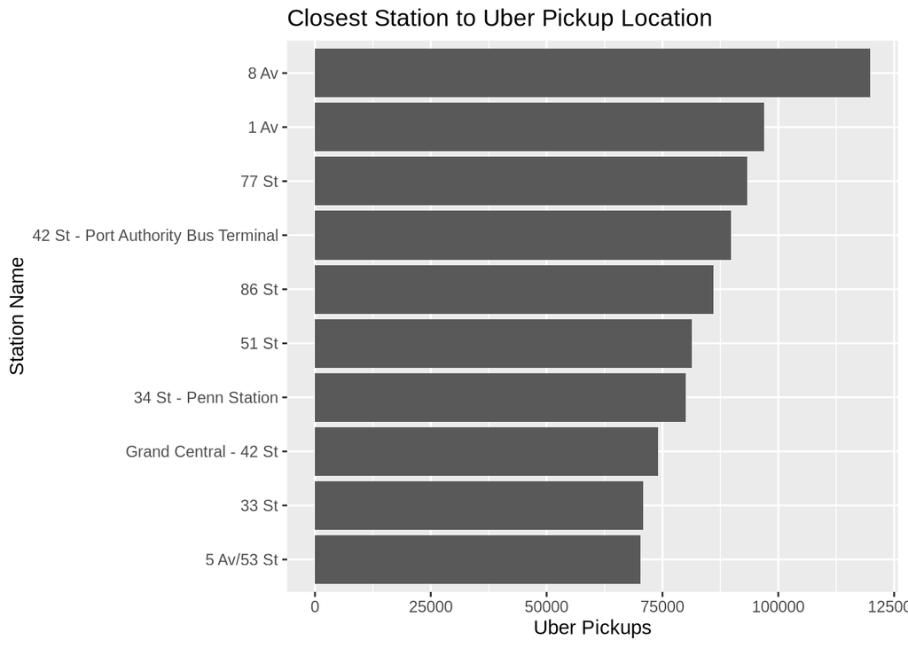

```r
most_popular_stations %>% head(10) %>%
  ggplot(aes(reorder(StationName, n), n)) +
  geom_bar(stat='identity') +
  coord_flip() +
  ggtitle("Closest Station to Uber Pickup Location") +
  xlab("Station Name") +
  ylab("Uber Pickups")
```

It appears that the 8th Avenue stop is the station that is the most often the closest when a user calls for an Uber. This makes sense, since this is station covers a lot of area, being the closest station to the Meatpacking District. As a result, any Uber ride called in the area will be associated with this stop.

### Stations with Shortest Average Distance

We can also look at what stations had the average closest pickup distance

```r
closest_stations <- uber_station %>%
  group_by(StationName) %>%
  summarize(average_dist = mean(Distance)) %>%
  arrange(average_dist)
closest_stations %>% head(10)
```

```
## # A tibble: 10 x 2
##    StationName           average_dist
##    <chr>                        <dbl>
##  1 World Trade Center      0.00000124
##  2 Hoyt St                 0.00000135
##  3 18 St                   0.00000217
##  4 Times Sq - 42 St        0.00000245
##  5 57 St - 7 Av            0.00000250
##  6 Broadway-Lafayette St   0.00000264
##  7 49 St                   0.00000280
##  8 Whitehall St            0.00000281
##  9 57 St                   0.00000295
## 10 Bowery                  0.00000298
```

These stations all have a very close average pickup distance. However, this might be due to the fact that there are many other subway stations nearby and resultingly, the station covers little area. In the case of the World Trade Center, there are plenty of other subway stations in financial district. The Hoyt Street station shares the same story, since it is located right between the Jay Street-Metrotech station and DeKalb Ave.

### Distance To Closest Station

Given that all of the the locations were recorded purely by global coordinates, calculating the distance in an interpretable manner is difficult. Luckily, there is an approximation for distance. 1 degree of latitude or longitude is approximately 60 miles (69 miles for latitude, 54 miles for longitude). Using this, and knowing that the KNN used squared distance, I will calculate the distance in feet.

```r
uber_distance <- uber_station %>%
  mutate(`Distance` = sqrt(`Distance`)*60*5280)

median_uber_distance <- median(uber_distance$Distance)

median_uber_distance
```

```
## [1] 847.0128
```

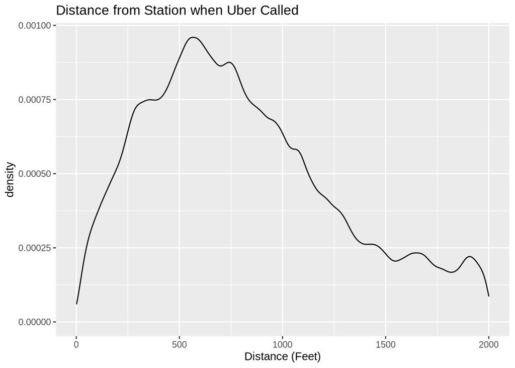

```r
uber_distance %>%
  filter(Distance < 2000) %>%
  ggplot() +
  geom_density(aes(`Distance`)) +
  ggtitle("Distance from Station when Uber Called") +
  xlab("Distance (Feet)")
```

As seen above, the median distance for an Uber call is 847 feet. Given that each NYC block is about 264 feet (https://streeteasy.com/blog/how-many-nyc-blocks-are-in-one-mile/), this is about 3.2 blocks.

### Date and Time

One aspect I wanted to examine was at what times of day are calling Uber rides most common. This metric has little to do with a comparison to the MTA, but rather just a pure insight into when users need rides.

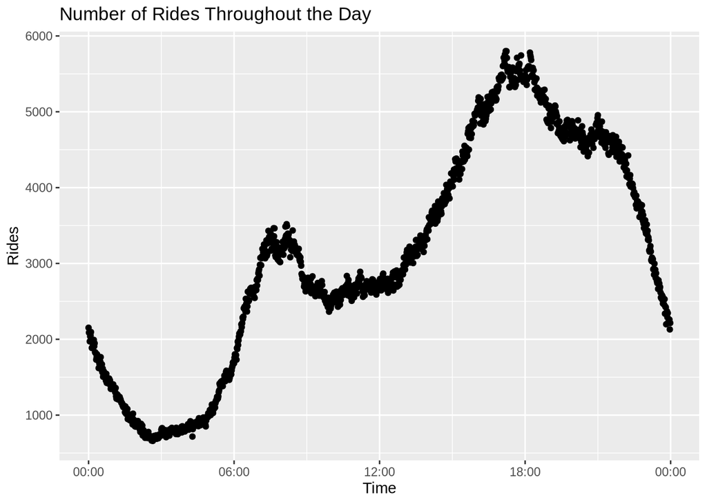

```r
uber_station_time <- uber_station %>%
  mutate(`Day` = as.Date(`Date`, format="%Y-%m-%d"), `Time` = format(`Date`, format="%H:%M:%S")) %>%
  mutate(`Time` = as.POSIXct(strptime(`Time`, format="%H:%M:%S")))

uber_station_time %>%
  group_by(`Time`) %>%
  summarize(n()) %>%
  ggplot(aes(`Time`, `n()`)) +
  geom_point() +
  scale_x_datetime(labels = function(x) format(x, format = "%H:%M")) +
  ylab("Rides") +
  ggtitle("Number of Rides Throughout the Day")
```

Additionally, I wanted to look at ridership based on the day of the week.

```r
uber_station_time_day <- uber_station_time %>%
  mutate(`WeekDay` = weekdays(`Date`))

week_day_count <- uber_station_time_day %>%
  distinct(`Day`, .keep_all=TRUE) %>%
  group_by(`WeekDay`) %>%
  summarize(`DayCount` = n())

week_day_count
```

[output not shown]

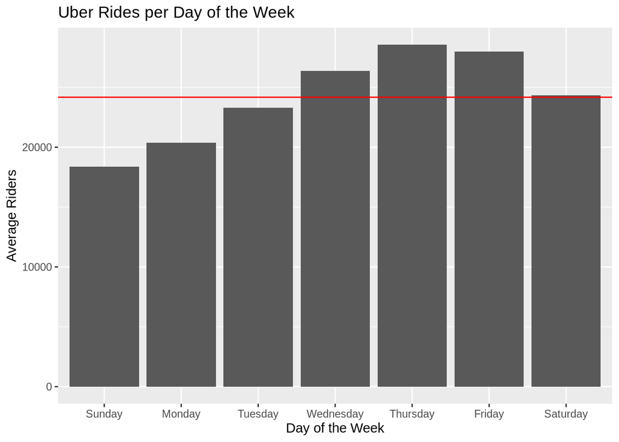

```r
uber_ride_day <- uber_station_time %>%
  group_by(`Day`) %>%
  summarize(n())

uber_avg_ride_per_day <- mean(uber_ride_day['n()'][[1]])

uber_station_time_day %>%
  group_by(`WeekDay`) %>%
  summarize('Riders' = n()) %>%
  left_join(week_day_count, by='WeekDay') %>%
  mutate(`Average Riders` = `Riders`/`DayCount`) %>%
  mutate(`WeekDay` = as.factor(`WeekDay`)) %>%
  ggplot(aes(x = factor(WeekDay, levels=c("Sunday", "Monday", "Tuesday", "Wednesday", "Thursday", "Friday", "Saturday")), `Average Riders`)) +
  geom_bar(stat="identity") +
  geom_hline(yintercept=uber_avg_ride_per_day, color="red") +
  xlab("Day of the Week") +
  ggtitle("Uber Rides per Day of the Week")
```

The overall average riders per day is displayed as the red line. It appears that ridership increases as the week goes on.

### Weather

One suggestion was to incorporate weather, which I thought was an excellent idea. I gathered weather data from https://www.ncdc.noaa.gov/cdo-web/, which allows you to “order” a dataset for free. I used their tool to get weather data from Central Park from 01-01-2014 to 12-31-2014. This dataset contains metrics about temperature as well as precipitation.

```r
weather_raw <- read_csv(here("data", "weather.csv"))
```

I extracted the columns that I needed from the data - the date, the amount of precipitation, and the temperature.

```r
weather <- weather_raw %>%
  select(`DATE`, `PRCP`, `TMAX`) %>%
  rename(`Day`=`DATE`, `Rain`=`PRCP`, `Temperature`=`TMAX`)

weather %>% head(10)
```

```
## # A tibble: 10 x 3
##    Day         Rain Temperature
##    <date>     <dbl>       <dbl>
##  1 2014-01-01  0             33
##  2 2014-01-02  0.33          33
##  3 2014-01-03  0.29          18
##  4 2014-01-04  0             29
##  5 2014-01-05  0.14          40
##  6 2014-01-06  0.36          55
##  7 2014-01-07  0             19
##  8 2014-01-08  0             22
##  9 2014-01-09  0             32
## 10 2014-01-10  0.11          37
```

The first thing I will examine is the effect of temperature of Uber ridership.

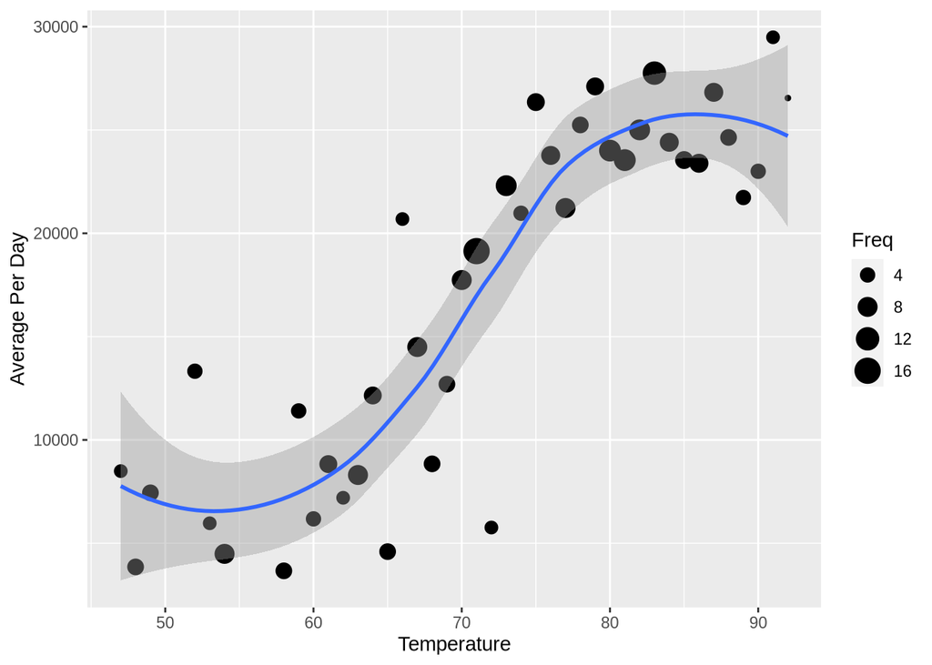

```r
uber_station_weather <- uber_station_time %>%
  left_join(weather, by='Day')

# Get relative frequency for weather
weather_temp_dist <- weather %>%
  group_by(`Temperature`) %>%
  summarize(`Freq` = n())

uber_station_weather %>%
  group_by(`Temperature`) %>%
  summarize(n()) %>%
  left_join(weather_temp_dist, by='Temperature') %>%
  mutate(`Average Per Day` = `n()` / `Freq`) %>%
  ggplot(aes(`Temperature`, `Average Per Day`)) +
  geom_point(aes(size=`Freq`)) +
  geom_smooth()
```

It appears that there more Uber rides called in warmer weather. This seems like it may be due to more people wanting to go outside when the weather is nice.

On the topic of nice weather, I will also investigate the effect of rain on ridership.

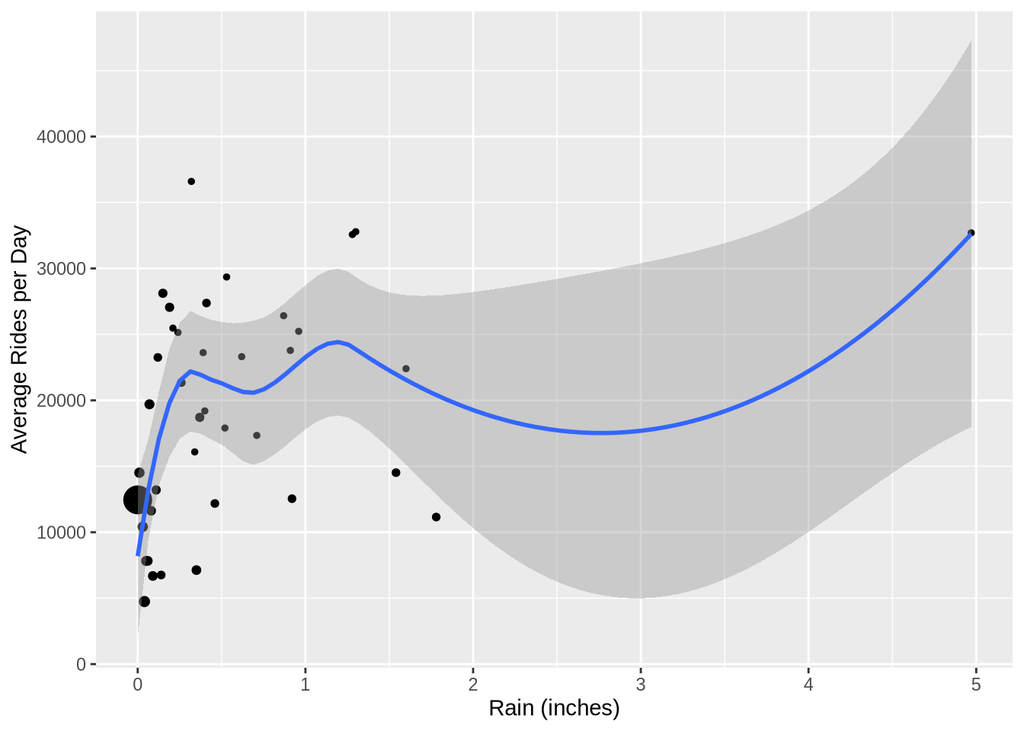

```r
weather_rain_dist <- weather %>%
  group_by(`Rain`) %>%
  summarize(`Freq` = n())



uber_station_weather %>%
  group_by(Rain) %>%
  summarize(n()) %>%
  left_join(weather_rain_dist, by='Rain') %>%
  mutate(`Average Per Day` = `n()` / `Freq`) %>%
  ggplot(aes(`Rain`, `Average Per Day`)) +
  geom_point(aes(size=`Freq`)) +
  geom_smooth() +
  ylab("Average Rides per Day") +
  xlab("Rain (inches)") +
  theme(legend.position="none")
```

While there is a singular outlier day where there were 5 inches of rain, it appears that overall, ridership is increased when there is rain. The large black dot where there is zero inches of rain indicates ridership on a clear day. The vast majority of the days with any precipitation have many more rides.